# Stawberries

Author

MA615

Published

October 14, 2024

# Strawberries: Data

This is a project abo ut acquiring strawberry data from the USDA-NASS system and then cleaning, organizing, and exploring the data in preparation for data analysis. To get started, I acquired the data from the USDA NASS system and downloaded them in a csv.

## Data cleaning and organization references

[“An introduction to data cleaning with R” by Edwin de Jonge and Mark van der Loo](https://cran.r-project.org/doc/contrib/de_Jonge+van_der_Loo-Introduction_to_data_cleaning_with_R.pdf)

“Problems, Methods, and Challenges in Comprehensive Data Cleansing” by Heiko Müller and Johann-Christoph Freytag

## Questions about Strawberries

- Where they are grown? By whom?
- Are they really loaded with carcinogenic poisons?
- Are they really good for your health? Bad for your health?
- Are organic strawberries carriers of deadly diseases?
- When I go to the market should I buy conventional or organic strawberries?
- Do Strawberry farmers make money?
- How do the strawberries I buy get to my market?

## Strawberry data source and parameters

The data set for this assignment has been selected from:

[[USDA_NASS_strawb_2024SEP25](https://quickstats.nass.usda.gov).

The data have been stored on NASS here: [USDA_NASS_strawb_2024SEP25](https://quickstats.nass.usda.gov/results/28141CE5-7429-36C3-A385-33ACC8030763) .

For the assignment, I stored the csv I downloaded on the MA615 Blackboard as strawberries25_v3.csv.

There are 5,359 rows and 21 column in the initial data set. The only complete year is 2022, although there is data for years 2018 through 2024.

To work with the data, define a function to remove columns with only single value in all its rows.

To work with this data, split the Census data from the Survey data.

## Census data cleaning and organizing

we’re examining census data because it’s different from survey data

we’re isolating organic data

Note that straw_cen has only one year: 2022

Current stats Census date has been isolated and split between Organic and Conventional strawberries

### imputed values

We’ll start with missing value interpolation for census data:

We will first interpolate the Bearing “Grown” values. Then we can interpolate Bearing and Non-bearing from those values as we discussed in lecture.

Now if GROWN is NA, there are three possibilities:

**1** Bearing and Non-bearing are both NA  
**2** Neither Bearing nor Non-bearing are NA  
**3** One of Bearing nor Non-bearing are NA

The solution for each of these cases is different:

**1** Interpolate from the total for area grown(a check of the dataframe shows you that the total is never NA). We’ll try and calculate the average ratio of the missing parts across the non-missing data and split the difference from the total across those  
**2** Sum Bearing and non-bearing. Easy.

**3** Calculate the average proportion of grown that bearing or non bearing(as the case may be) is for the state in question. Then we use that to figure out the value.

Applying our functions now to strawberry census:

Now that we have imputed the values, we still have an adjustment to make. Because we are using proportional averages, the values might no longer add up to our totals. So we need to write a function that will scale our imputed values so that the totals add up.

The happy news is because we are doing this by index, we still know which are the values we have imputed and therefore which values we need to scale.

### Imputing acres bearing and non-bearing

We can go one better with imputation where we impute case 1 for the “GROWN” categories together with other case 1s for each. A slight modification to the function above plus some other changes achieves this.

## Survey data cleaning and organizing

Shift data into alignment function

Examine Domain

now look at totals

there are two markets for Strawberries – Fresh Marketing and Processing

make a table for each

from the Survey Totals

we have reports for

Markets: Fresh and Processing Operations: Growing and Production

### Florida - California - 2018 -2023

### California and Florida chemicals

### California and Florida fertilizers

```r
library(ggplot2)
library(dplyr)
library(tidyverse)
chemical<- read.csv("new.csv", header = TRUE)
head(chemical)
```

```
  Year      State          mk2                 measure other chem_name   Value
1 2023 CALIFORNIA APPLICATIONS                      LB  <NA>  NITROGEN 393,000
2 2023 CALIFORNIA APPLICATIONS                      LB  <NA> PHOSPHATE 216,000
3 2023 CALIFORNIA APPLICATIONS                      LB  <NA>    POTASH 393,000
4 2023 CALIFORNIA APPLICATIONS                      LB  <NA>    SULFUR     (D)
5 2023 CALIFORNIA APPLICATIONS LB / ACRE / APPLICATION   AVG  NITROGEN      13
6 2023 CALIFORNIA APPLICATIONS LB / ACRE / APPLICATION   AVG PHOSPHATE      10
```

#Chemical Distribution

In the first step, I plan to use cleaned data named “new” from USDA-NASS data cleaning-ver7.qmd file. Since only Florida and California used chemicals, it is easy to start with total chemical used.

[figure not shown]

```r
#Total Chemical
data_chem<- chemical %>%
  filter(Year %in% c("2018", "2019", "2023") & State %in% c("CALIFORNIA", "FLORIDA")& chem_name %in% c("NITROGEN", "PHOSPHATE", "POTASH", "SULFUR")& measure=="LB")

ggplot(data_chem, aes(x = factor(Year), y = Value, fill = chem_name))+
  geom_bar(stat = "identity", position = "dodge")+
  facet_wrap(~ State)+
  labs(
       x = "Year",
       y = "Application Amount(LB)")+
  theme_minimal()
```

#Plot “PCT OF AREA BEARING”

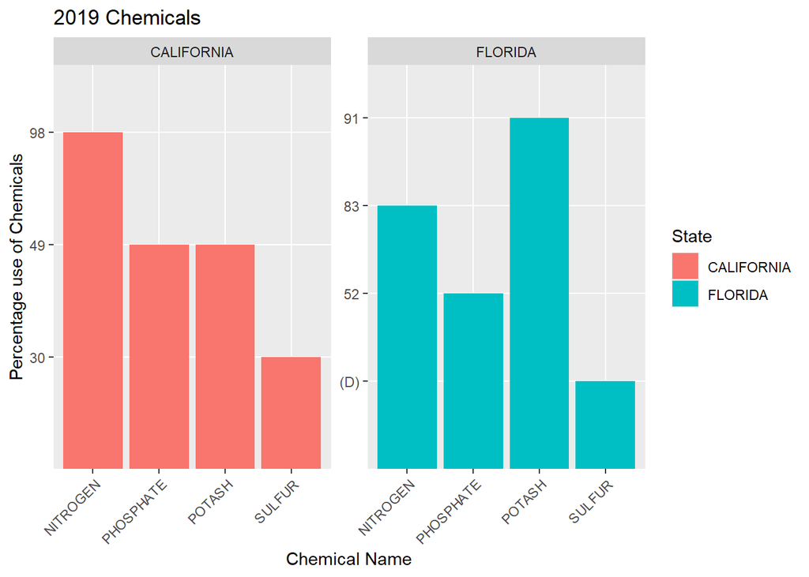

```r
data_chem1<- chemical %>%
  filter(Year == 2019 & State %in% c("CALIFORNIA", "FLORIDA")& chem_name %in% c("NITROGEN", "PHOSPHATE", "POTASH", "SULFUR")& measure=="PCT OF AREA BEARING")
#Plot the growth rate under different chemicals.
ggplot(data_chem1, aes(x = chem_name, y = Value, fill = State))+
  geom_bar(stat = "identity", position = "dodge")+
  facet_wrap(~ State, scales = "free")+
  labs(title = "2019 Chemicals",
       x = "Chemical Name",
       y = "Percentage use of Chemicals",
       fill = "State")+
  theme(axis.text.x = element_text(angle= 45, hjust =1))
```

```r
  theme_minimal()
```

[output not shown]

[output cut: 240 more lines]

[output not shown]

#Plot “LB / ACRE / YEAR”

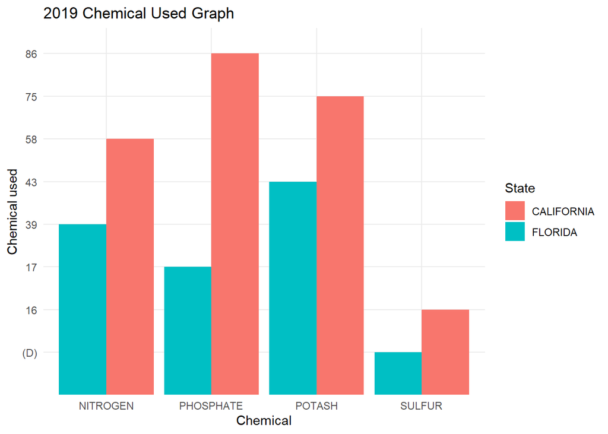

```r
data_chem2<- chemical %>%
  filter(Year == 2019 & State %in% c("CALIFORNIA", "FLORIDA")& chem_name %in% c("NITROGEN", "PHOSPHATE", "POTASH", "SULFUR")& measure=="LB / ACRE / YEAR")

#Plot the use of chemical graph
ggplot(data_chem2, aes(x = chem_name, y = Value, fill = State))+
  geom_bar(stat = "identity", position = "dodge")+
  labs(title = "2019 Chemical Used Graph",
       x = "Chemical",
       y = "Chemical used")+
  theme_minimal()
```

But why they choose Nitrogen and Potash? We can start from fungicide and insecticide.

## Chemicals usd in strawberry cultivaion

### Six deadly carcinogens from WHO list

[captafol](https://en.wikipedia.org/wiki/Captafol)

[ethylene dibromide](https://en.wikipedia.org/wiki/1,2-Dibromoethane) [also](https://www.epa.gov/sites/default/files/2016-09/documents/ethylene-dibromide.pdf)

[glyphosate](https://en.wikipedia.org/wiki/Glyphosate) See also [1](https://www.ewg.org/areas-focus/toxic-chemicals/glyphosate)  
[2](https://www.ncbi.nlm.nih.gov/pmc/articles/PMC9101768/)  
[3](http://npic.orst.edu/factsheets/glyphogen.html)  
[4](https://www.epa.gov/ingredients-used-pesticide-products/glyphosate)

[malathion](https://en.wikipedia.org/wiki/Malathion) [1](https://www.epa.gov/mosquitocontrol/malathion) [2](http://npic.orst.edu/factsheets/malagen.html)

[diazinon](https://en.wikipedia.org/wiki/Diazinon) [1](https://wwwn.cdc.gov/TSP/PHS/PHS.aspx?phsid=511&toxid=90#:~:text=Diazinon%20is%20the%20common%20name,Dazzel%2C%20Gardentox%2C%20and%20Knoxout.) [2](http://npic.orst.edu/factsheets/Diazgen.html) [3](https://earthjustice.org/feature/organophosphate-pesticides-united-states/diazinon)

[dichlorophenyltrichloroethane (DDT)](https://en.wikipedia.org/wiki/DDT) [1](https://www.acs.org/molecule-of-the-week/archive/d/dichlorodiphenyltrichloroethane.html) [2](https://www.ncbi.nlm.nih.gov/pmc/articles/PMC1240724/) [3](https://www.epa.gov/ingredients-used-pesticide-products/ddt-brief-history-and-status#:~:text=DDT%20(dichloro%2Ddiphenyl%2Dtrichloroethane,both%20military%20and%20civilian%20populations.)

### For contrast

Azadirachtin [1](https://pubchem.ncbi.nlm.nih.gov/compound/Azadirachtin#section=2D-Structure) [2](https://www.acs.org/molecule-of-the-week/archive/a/azadirachtin.html#:~:text=Azadirachtin%20is%20an%20impressive%20molecule,and%20four%20carboxylic%20acid%20esters.) [3](http://npic.orst.edu/factsheets/neemgen.html)

### Sources of agricultural chemical information

for EPA number lookup [epa numbers](https://archive.epa.gov/pesticides/chemicalsearch/chemical/foia/web/html/128810.html)

[Active Pesticide Product Registration Informational Listing](https://ordspub.epa.gov/ords/pesticides/f?p=APPRIL_PUBLIC:2::::::)

[CAS for Methyl Bromide](https://ordspub.epa.gov/ords/pesticides/f?p=113:17::::::)

[pesticide chemical search](https://ordspub.epa.gov/ords/pesticides/f?p=chemicalsearch:1)

[toxic chemical dashboard](https://comptox.epa.gov/dashboard/)

[pubChem](https://pubchem.ncbi.nlm.nih.gov/)

The EPA PC (Pesticide Chemical) Code is a unique chemical code number assigned by the EPA to a particular pesticide active ingredient, inert ingredient or mixture of active ingredients.

Investigating toxic pesticides

[start here with chem PC code](https://ordspub.epa.gov/ords/pesticides/f?p=chemicalsearch:1)

[step 2](https://ordspub.epa.gov/ords/pesticides/f?p=113:1::::RP,17,1::) to get label (with warnings) for products using the chemical

[Pesticide Product and Label System](https://ordspub.epa.gov/ords/pesticides/f?p=113:1::::RP,17,1::)

[Search by Chemical](https://ordspub.epa.gov/ords/pesticides/f?p=113:17::::::)

[CompTox Chemicals Dashboard](https://comptox.epa.gov/dashboard/)

[Active Pesticide Product Registration Informational Listing](https://ordspub.epa.gov/ords/pesticides/f?p=APPRIL_PUBLIC:2::::::)

[OSHA chemical database](https://www.osha.gov/chemicaldata)

[Pesticide Ingredients](http://npic.orst.edu/ingred/)

[NPIC Product Research Online (NPRO)](http://npic.orst.edu/NPRO/)

[Databases for Chemical Information](http://npic.orst.edu/ingred/cheminfo.html)

[Pesticide Active Ingredients](http://npic.orst.edu/ingred/active.html)

[TSCA Chemical Substance Inventory](https://www.epa.gov/tsca-inventory)

[glyphosate](https://ordspub.epa.gov/ords/pesticides/f?p=CHEMICALSEARCH:3::::1,3,31,7,12,25:P3_XCHEMICAL_ID:2478)